# week3 hmwrk

```r
library(rethinking)
library(dagitty)
```

1. The first two problems are based on the same data. The data in data(foxes) are 116 foxes from 30 different urban groups in England. These fox groups are like street gangs. Group size (groupsize) varies from 2 to 8 individuals. Each group maintains its own (almost exclusive) urban territory. Some territories are larger than others. The area variable encodes this information. Some territories also have more avgfood than others. And food influences the weight of each fox. Assume this DAG:

where F is avgfood, G is groupsize, A is area, and W is weight. Use the backdoor criterion and estimate the total causal influence of A on F. What effect would increasing the area of a territory have on the amoutn of food inside it.

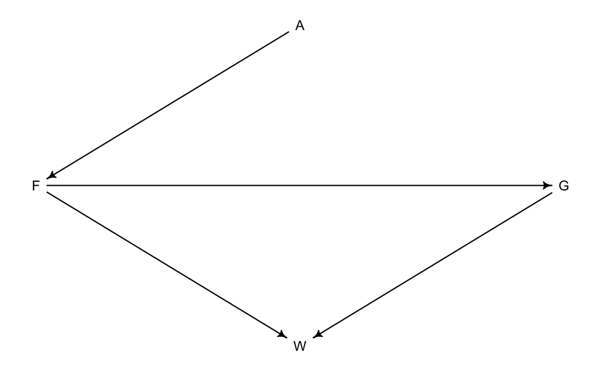

```r
dag.w3q1 <- dagitty("dag {
    A -> F
    F -> G
    F -> W
    G -> W
}")
coordinates(dag.w3q1) <- list(x =c(F=0, A=1, W=1, G=2),
                              y=c(A=0, F=1, G=1, W=2))
drawdag(dag.w3q1)
```

There is a direct line from A -> F, and there are no other paths going into F, let alone any other paths from A. The total causal influence of A on F can be estimated using a single linear regression.

Just to check, we can see what dagitty tells us

```r
adjustmentSets(dag.w3q1, exposure="A", outcome="F")
```

```
 {}
```

```r
data(foxes)
f <- foxes
```

```r
#standardize variables
f$A <- scale(f$area)
f$F <- scale(f$avgfood)
f$W <- scale(f$weight)
f$G <- scale(f$groupsize)
```

```r
m.w3q1 <- quap(
  alist(
    F ~ dnorm(mu, sigma),
    mu <- a + bA*A,
    a ~ dnorm(0, 0.2),
    bA ~ dnorm(0, 0.5),
    sigma ~ dexp(1)
  ), data = f)
```

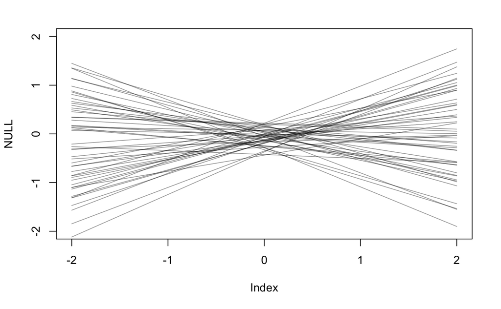

```r
#simluate from priors
set.seed(10)
prior <- extract.prior(m.w2q1)
mu <-link(m.w2q1, post=prior, data=list(A=c(-2, 2)))
plot(NULL, xlim=c(-2, 2), ylim=c(-2,2))
for (i in 1:50) lines( c(-2, 2), mu[i,], col=col.alpha("black", 0.4))
```

```r
precis(m.w3q1)
```

|  | mean | sd | 5.5% | 94.5% |
| --- | --- | --- | --- | --- |
| a | 0.00 | 0.04 | -0.07 | 0.07 |
| bA | 0.88 | 0.04 | 0.81 | 0.95 |
| sigma | 0.47 | 0.03 | 0.42 | 0.52 |

An increase in area has a large causal effect on increasing F.

2. Now infer both the total and direct causal effects of adding food F to a territory on the weight W of foxes. Which covariates do you need to adjust for in each case? In light of your estimates from this problem and the previous one, what do you tink is going on with these foxes? Feel free to speculate – all that matters is that you justify your speculation.

That total effect of F on W can be estimated with a single regression on F.

```r
m.w3q2a <- quap(
  alist(
    W ~ dnorm(mu, sigma),
    mu <- a + bF*F,
    a ~ dnorm(0, 0.2),
    bF ~ dnorm(0, 0.5),
    sigma ~ dexp(1)
  ), data = f)
precis(m.w3q2a)
```

|  | mean | sd | 5.5% | 94.5% |
| --- | --- | --- | --- | --- |
| a | 0.00 | 0.08 | -0.13 | 0.13 |
| bF | -0.02 | 0.09 | -0.17 | 0.12 |
| sigma | 0.99 | 0.06 | 0.89 | 1.09 |

An increase in food has a neglibile total effect on W.

The direct effect of F on W can be estimated with a multiple regression on F and G.

```r
m.w3q2b <- quap(
  alist(
    W ~ dnorm(mu, sigma),
    mu <- a + bF*F +bG*G,
    a ~ dnorm(0, 0.2),
    bF ~ dnorm(0, 0.5),
    bG ~ dnorm(0, 0.5),
    sigma ~ dexp(1)
  ), data = f)
precis(m.w3q2b)
```

|  | mean | sd | 5.5% | 94.5% |
| --- | --- | --- | --- | --- |
| a | 0.00 | 0.08 | -0.13 | 0.13 |
| bF | 0.48 | 0.18 | 0.19 | 0.76 |
| bG | -0.57 | 0.18 | -0.86 | -0.29 |
| sigma | 0.94 | 0.06 | 0.84 | 1.04 |

After considering the effects of both food and groupsize on weight, we see that increasing food now has a clear direct effect on increasing weight, while groupsize has a clear negative effect on weight.

It could be that the increasing availability of food leads to increasing groupsize, which leads to more competition for food, the extent that the total casual effect of food on weight is negligible.

3. Reconsider the Table 2 Fallacy example (from Lecture 6), this time with an unobserved confound U that influences both smoking S and stroke Y. Here’s the modified DAG.

First use the backdoor criterion to determine an adjustment set that allows you to estimate the causal effect of X on Y, i.e. P(Y|do(X)). Second explain the proper interpretation of each coefficent implied by the regression model that corresponds to the adjustment set. Which coefficents (slopes) are causal and which are not? There is no need to fit any models. Just think through the implications.

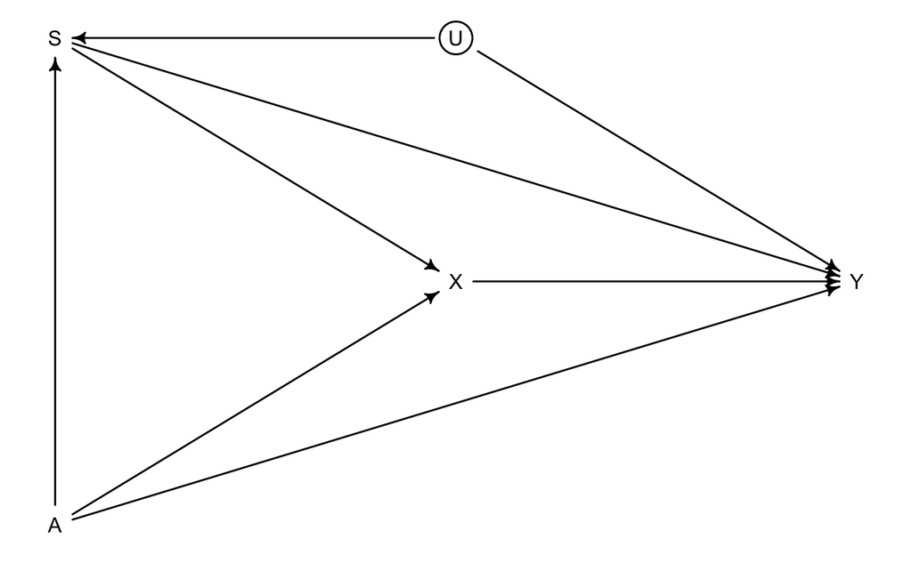

```r
dag.w3q3 <- dagitty("dag {
    U [unobserved]
    A -> S
    A -> X
    A -> Y
    S -> X
    S -> Y
    S -> X
    X -> Y
    U -> S
    U -> Y
}")
coordinates(dag.w3q3) <- list(x =c(S=0, A=0, X=1, U=1, Y=2),
                              y = c(S=0, U=0, X=1, Y=1, A=2))
drawdag(dag.w3q3)
```

To estimate the causal effect of X on Y, we need to close other paths leading from X to Y other than the direct path.

These other paths are:

1. X <- S -> Y  
   open, no collider backdoor, has arrow entering X
2. X <- S <- U -> Y open, no collider backdoor, has arrow entering X
3. X <- S <- A -> Y open, no collider backdoor, has arrow entering X
4. X <- A -> Y open, no collider backdoor, has arrow entering X

S and A could be closed

```r
# check with daggitty
adjustmentSets(dag.w3q3, exposure="X", outcome="Y")
```

```
{ A, S }
```

```r
impliedConditionalIndependencies(dag.w3q3)
```

A regression model can be built with X, A, and S as the variables. The direct causal effect of X on Y can be found by stratifying over A, S, which means taking a sum over their distributions.